# Quantifying the therapeutic alliance: A methodological framework for conducting observational moment-by-moment research

This is a step-by-step guide to illustrate the contents of the paper *“Quantifying the therapeutic alliance: A methodological framework for conducting observational moment-by-moment research”*.

# 1. Preprocessing (observational data)

## 1.1 Load the observational data and merge the different files

Sometimes, data from different observations are stored in separate files. To prepare the data, we will merge them into a single file. The Observer XT provides `.xlsx` data files that contain several variables. For the data analysis, only a few of them are relevant:

- *Behavior*: Contains the names of the coded events in a longitudinal format.
- *Observation*: Contains the name assigned to each observation session. When coding, researchers must ensure that each session has a unique name. A common practice is to include an ID for the case and the session number (e.g., `case1_session1`). This variable represents repeated measures in a long format, as it includes all coded events within a session.
- *Subject*: Identifies the individual who emits the behavior (e.g., “Therapist” or “Client”).

The researcher may choose to retain the remaining variables. However, for simplicity, we will remove them since they are not needed for our analyses. If the researcher chooses to retain the additional variables and the data frames contain different variables (as in our case), the merge function should be used.

```r
library(readxl)

# Load the data files

data_1 <- read_excel("data_1.xlsx")[, c("Observation", "Subject", "Behavior")]
data_2 <- read_excel("data_2.xlsx")[, c("Observation", "Subject", "Behavior")]
data_3 <- read_excel("dyad 31.xlsx")[, c("Observation", "Subject", "Behavior")]
data_4 <- read_excel("dyad 32.xlsx")[, c("Observation", "Subject", "Behavior")]



# Merge the data (only three variables)

data <- rbind(data_1, data_2, data_3, data_4)


library(writexl)
write_xlsx(data, "Previous data.xlsx")

# Maintain the remaining variables

data <- Reduce(function(x, y) merge(x, y, by = c("Observation", "Subject", "Behavior"), all = T),
                      list(data_1, data_2, data_3, data_4))
```

## 1.2 Assign the sessions to the remaining variables: Phase of therapy, ID, Group

```r
library(readxl)

data <- read_excel("Previous data.xlsx")



# ASSIGN ID & Treatment phase

# Visualize the list of Observation sessions

unique_sessions <- unique(data$Observation)

unique_sessions <- as.data.frame(unique_sessions)


# Assign ID and Treatment phases based on the list of Observation sessions

session_lookup <- data.frame(
  Observation = unique(data$Observation),
  ID = rep(1:32, times = c(5, 5, 5, 5, 5, 5, 3, 5, 5, 5, 4, 5, 5, 5, 5, 5, 5, 5, 3, 5, 5, 5, 5, 5, 4, 5, 5, 5, 5, 5, 5, 5)),
  Treatment_Phase = c("Middle of intervention", "End of intervention", "Assessment", "Treatment planning", "Beginning of intervention",
                      "End of intervention","Assessment","Treatment planning","Beginning of intervention","Middle of intervention",
                      "Middle of intervention","End of intervention","Assessment","Treatment planning","Beginning of intervention",
                      "Beginning of intervention","Middle of intervention", "Assessment", "End of intervention", "Treatment planning",
                      "Middle of intervention","End of intervention","Assessment","Treatment planning","Beginning of intervention",
                      "Beginning of intervention","Middle of intervention","End of intervention","Assessment","Treatment planning",
                      "Assessment","Treatment planning","Beginning of intervention",
                      "Middle of intervention","End of intervention","Assessment","Treatment planning","Beginning of intervention",
                      "Middle of intervention","End of intervention","Assessment","Treatment planning","Beginning of intervention",
                      "Middle of intervention","End of intervention","Assessment","Treatment planning","Beginning of intervention",
                      "Assessment","Treatment planning","Beginning of intervention", "End of intervention",
                      "Middle of intervention","End of intervention","Assessment","Treatment planning","Beginning of intervention",
                      "Beginning of intervention","Middle of intervention","End of intervention","Assessment","Treatment planning",
                      "Middle of intervention","Assessment", "End of intervention", "Treatment planning","Beginning of intervention",
                      "Beginning of intervention","Middle of intervention","End of intervention","Assessment","Treatment planning",
                      "Middle of intervention","End of intervention","Assessment","Treatment planning","Beginning of intervention",
                      "Middle of intervention","End of intervention","Assessment","Beginning of intervention","Treatment planning",
                      "Beginning of intervention","Middle of intervention","End of intervention","Assessment","Treatment planning",
                      "Assessment","Treatment planning","Beginning of intervention",
                      "End of intervention","Assessment","Treatment planning","Beginning of intervention","Middle of intervention",
                      "Beginning of intervention","Middle of intervention","Assessment","End of intervention","Treatment planning",
                      "Beginning of intervention","Middle of intervention","Assessment","End of intervention","Treatment planning",
                      "Middle of intervention","End of intervention","Assessment","Treatment planning","Beginning of intervention",
                      "Middle of intervention","End of intervention","Assessment","Treatment planning","Beginning of intervention",
                      "Assessment","Treatment planning","Beginning of intervention","End of intervention",
                      "Middle of intervention","End of intervention","Assessment","Treatment planning","Beginning of intervention",
                      "End of intervention","Assessment","Treatment planning","Beginning of intervention","Middle of intervention",
                      "Beginning of intervention","Middle of intervention","End of intervention","Assessment","Treatment planning",
                      "Middle of intervention","End of intervention","Assessment","Treatment planning","Beginning of intervention",
                      "End of intervention","Assessment","Treatment planning","Beginning of intervention","Middle of intervention",
                      "Middle of intervention","End of intervention","Assessment","Treatment planning","Beginning of intervention",
                      "Middle of intervention","End of intervention","Assessment","Treatment planning","Beginning of intervention"
                      )
)


# Merge the assigned IDs and Treatment phases with the rest of data

library(dplyr)

data_merged <- left_join(data, session_lookup, by = "Observation")


# Check phases' names for potential typos

#unique(data_merged$Treatment_Phase)


##################################################################################

# ASSIGN GROUPS

# Visualize the list of IDs

unique_ID <- unique(data_merged$ID)

unique_ID <- as.data.frame(unique_ID)

# Assign Groups based on the list of IDs

ID_lookup <- data.frame(
  ID = unique(data_merged$ID),
  Group = c("Poor", "Poor", "Good", "Poor", "Poor", "Good", "Poor", "Good", "Good", "Poor", "Good", "Good", "Poor", "Good", "Good", "Poor", "Poor", "Good", "Poor", "Good", "Average", "Average", "Average", "Average", "Average", "Average", "Average", "Average", "Average", "Average", "Average", "Average")
)


# Merge the assigned Grups with the rest of data

data_complete <- left_join(data_merged, ID_lookup, by = "ID")

# Check Groups' names for potential typos

#unique(data_complete$Group)

head(data_complete)
```

| Observation | Subject | Behavior | ID | Treatment_Phase | Group |
| --- | --- | --- | --- | --- | --- |
| Dyad1_Session 10_Middle | Client | Providing information C | 1 | Middle of intervention | Poor |
| Dyad1_Session 10_Middle | Therapist | Total agreement T | 1 | Middle of intervention | Poor |
| Dyad1_Session 10_Middle | Client | Total agreement C | 1 | Middle of intervention | Poor |
| Dyad1_Session 10_Middle | Client | Providing information C | 1 | Middle of intervention | Poor |
| Dyad1_Session 10_Middle | Therapist | Total agreement T | 1 | Middle of intervention | Poor |
| Dyad1_Session 10_Middle | Therapist | Self-disclosure personal life T | 1 | Middle of intervention | Poor |

```r
library(writexl)
write_xlsx(data_complete, "Preprocessed data - phase names.xlsx")
```

## 1.3 Permanent grouping of behaviors

Some behaviors, either for theoretical reasons or due to their low frequency, need to be grouped. In future sections, we will present a more flexible approach for grouping behaviors for specific analyses without the need to permanently modify the dataset. However, some researchers may prefer to group behaviors permanently beforehand if they are certain that these behaviors should remain unified under the same label. In such cases, researchers may find the `permanent_group` function useful.

- `permanent_group` allows researchers to group behaviors under a single label before conducting analyses. Its simple usage requires researchers to input the names of the behaviors to be grouped, separated by a `+` symbol, as well as the name of the variable that store the behaviors and the name of the new grouped behavior created.

```r
library(readxl)
data <- read_excel("Preprocessed data - phase names.xlsx")

permanent_group <- function(data, behavior_column, behaviors_to_group, new_group_name) {
  # Check if the behavior column exists in the data
  if (!(behavior_column %in% colnames(data))) {
    stop(paste("Warning: The column", behavior_column, "does not exist in the dataset. Please check the column name."))
  }

  # Split the input behaviors by "+" and remove extra spaces
  behaviors_list <- strsplit(behaviors_to_group, " \\+ ")[[1]]

  # Check if any of the behaviors in the list are already grouped
  grouped_behaviors <- data[[behavior_column]] %in% behaviors_list
  if (any(grouped_behaviors, na.rm = TRUE)) {
    # Check if the group is already present in the column, excluding NAs
    if (any(data[[behavior_column]] == new_group_name, na.rm = TRUE)) {
      warning(paste("The behavior(s) have already been grouped under", new_group_name, "and cannot be grouped again."))
    }
  }

  # Update the behavior column in the dataset, ignoring NA values
  data[[behavior_column]] <- sapply(data[[behavior_column]], function(x) {
    # If the behavior contains any of the specified behaviors, replace them with the new group name
    if (is.character(x) && any(sapply(behaviors_list, function(b) grepl(b, x)))) {
      return(new_group_name)
    } else {
      return(x)
    }
  })

  # Return the modified dataset
  return(data)
}
```

As an example, the client behaviors `Partial agreement` and `Disagreement`, which are theoretically related, will be unified into the new behavior `Group_1`.

```r
data <- permanent_group(data, "Behavior", "Partial agreement C + Disagreement C", "Group_1")
```

After preprocessing the data and obtaining the final dataset, it is always good practice to store it safely to avoid losing information and repeating the entire process.

```r
library(writexl)
write_xlsx(data, "Preprocessed data.xlsx")
```

# 2. Descriptive statistics (observational data)

Descriptive data will be useful for future decisions regarding the analyses. To provide a comprehensive description of the data, the function `sequence_descriptives` is able to provide descriptive statistics for both individual behaviors and sequences of an indefinite number of behaviors. The contents of this section will, therefore, apply to both individual behaviors and sequences.

### Key Features

1. **Flexible Behavior Grouping**:
   - Researchers can group behaviors using the `+` symbol (e.g., `"BehaviorA + BehaviorB"`) to treat them as the same during analysis.
   - This grouping is applied dynamically and does not modify the original dataset.
2. **Descriptive Statistics**:
   - Computes the following statistics for each treatment phase:
     - **Sample size**: Number of observation sessions per phase.
     - **Mean**: Mean relative frequency of behaviors/sequences.
     - **Median**: Median relative frequency of behaviors/sequences.
     - **Standard deviation**: Variability of relative frequencies.
     - **Percentile 5**: 5th percentile of relative frequencies.
     - **Percentile 95**: 95th percentile of relative frequencies.
     - **Skewness**: Measure of distribution asymmetry.
     - **Standard error of skewness**: Error associated with skewness.
     - **Kurtosis**: Measure of distribution tailedness.
   - Includes the **Shapiro-Wilk test** for normality, with a `p-value` and a variable indicating whether the distribution is `Normal` or `Not normal`.
3. **Visualizations**:
   - Generates boxplots for each treatment phase.
   - Allows combining plots for all phases into a single display and group comparisons based on a variable (e.g. Intervention A vs Intervention B). Boxplots comparing groups could be displayed in the same plot or separated in different plots.
4. **Group Analysis**:
   - Provides options to filter and compare specific groups or phases.
5. **Relative or Absolute Frequencies**:
   - Allows absolute or relative frequencies analyses of behaviors/sequences per observation session.
6. **Requested Libraries Handling**:
   - Checks for required packages (`dplyr`, `ggplot2`, `gridExtra`, `e1071` and `stats` [included in the in base R]) and provides a warning if they are not installed.

### Function Arguments

| Argument | Description |
| --- | --- |
| `data` | The dataset containing the observations. It should be a `data.frame` where each row represents a subject’s observation within a phase of the treatment. |
| `treatment_phase_var` | The name of the variable that defines the treatment phase in the dataset (e.g., `"Treatment_Phase"`). This variable is used to group observations by phase. |
| `phase_order` | A vector specifying the order of the treatment phases to be analyzed. Example: `c("Phase1", "Phase2", "Phase3")`. If `NULL`, phases are ordered as they appear in the data. |
| `behavior_var` | The name of the variable containing the observed behaviors for each subject (e.g., `"Behavior"`). This variable should include behavior sequences to analyze. |
| `sequence` | A vector or list of strings specifying the behavior sequence to analyze. Use `+` to group behaviors (e.g., `c("BehaviorA + BehaviorB", "BehaviorC")`. |
| `combine_plots` | A logical value (`TRUE` or `FALSE`). If `TRUE`, boxes for all groups are combined into a single display. If `FALSE`, plots are displayed separately for each group. |
| `group_var` | The name of the grouping variable used to divide the data into different groups (e.g., `"Group"`). If `NULL`, the data is analyzed as a whole. |
| `selected_groups` | A vector of group names to filter and analyze. Example: `c("Group1", "Group2")`. If `NULL`, all groups in `group_var` are analyzed. |
| `use_relative_frequency` | A logical value (`TRUE` or `FALSE`). If `TRUE`, *relative* frequencies will be computed. If `FALSE`, *absolute* frequencies will be computed. |

### Function syntax

```r
library(readxl)
data <- read_excel("Preprocessed data - phase names.xlsx")

sequence_descriptives <- function(data, treatment_phase_var, phase_order, behavior_var, sequence,
                                  combine_plots = FALSE, group_var = NULL,
                                  selected_groups = NULL, use_relative_frequency = TRUE) {

  # Required packages
  required_packages <- c("dplyr", "ggplot2", "gridExtra", "e1071", "stats")
  missing_packages <- required_packages[!required_packages %in% installed.packages()[,"Package"]]
  if(length(missing_packages) > 0) {
    stop("The following required packages are missing: ", paste(missing_packages, collapse = ", "),
         "\nPlease install them using install.packages() before running the function.")
  }

  # Load packages quietly
  suppressPackageStartupMessages({
    library(dplyr, quietly = TRUE)
    library(ggplot2, quietly = TRUE)
    library(gridExtra, quietly = TRUE)
    library(e1071, quietly = TRUE)
    library(stats, quietly = TRUE)
  })

  process_behavior_group <- function(group) {
    strsplit(group, " \\+ ")[[1]]
  }

  # Convert phase_order to factor to maintain order
  phase_order <- factor(phase_order, levels = unique(phase_order))

  if (!is.null(group_var) && !is.null(selected_groups)) {
    data <- data %>% filter(.data[[group_var]] %in% selected_groups)
  }

  compute_sequence_frequencies <- function(treatment_phase, sequence, subset_data) {
    filtered_data <- subset_data %>%
      filter(.data[[treatment_phase_var]] == treatment_phase)

    sequence_data <- data.frame(
      Observation = unique(filtered_data$Observation),
      Sequence_Frequency = 0,
      Total_Possible_Sequences = 0,
      stringsAsFactors = FALSE
    )

    for (obs in sequence_data$Observation) {
      obs_data <- filtered_data %>% filter(Observation == obs)
      behavior_sequence <- obs_data[[behavior_var]]

      total_possible_sequences <- length(behavior_sequence) - length(sequence) + 1
      sequence_found <- 0

      if (total_possible_sequences > 0) {
        for (i in 1:total_possible_sequences) {
          window <- behavior_sequence[i:(i + length(sequence) - 1)]
          match_found <- TRUE

          for (j in seq_along(sequence)) {
            behavior_group <- process_behavior_group(sequence[j])
            if (!(window[j] %in% behavior_group)) {
              match_found <- FALSE
              break
            }
          }
          if (match_found) sequence_found <- sequence_found + 1
        }
      }

      sequence_data$Sequence_Frequency[sequence_data$Observation == obs] <- sequence_found
      sequence_data$Total_Possible_Sequences[sequence_data$Observation == obs] <- total_possible_sequences
    }

    if (use_relative_frequency) {
      sequence_data <- sequence_data %>%
        mutate(Frequency = ifelse(Total_Possible_Sequences > 0, Sequence_Frequency / Total_Possible_Sequences, 0))
    } else {
      sequence_data <- sequence_data %>%
        mutate(Frequency = Sequence_Frequency)
    }

    return(sequence_data)
  }

  # Prepare data frame for statistics
  all_phase_stats <- data.frame(
    Sequence = character(),
    Group = character(),
    Treatment_Phase = factor(character(), levels = levels(phase_order)),
    Sample_Size = integer(),
    Mean = numeric(),
    Median = numeric(),
    SD = numeric(),
    Percentile_5 = numeric(),
    Percentile_95 = numeric(),
    Skewness = numeric(),
    Skewness_SE = numeric(),
    Kurtosis = numeric(),
    Shapiro_p_value = numeric(),
    Normality = character(),
    stringsAsFactors = FALSE
  )

  # Prepare data frame for plotting
  all_plot_data <- data.frame(
    Observation = character(),
    Frequency = numeric(),
    Treatment_Phase = factor(character(), levels = levels(phase_order)),
    Group = character(),
    stringsAsFactors = FALSE
  )

  group_levels <- if (!is.null(group_var)) unique(data[[group_var]]) else list("All")

  for (group in group_levels) {
    subset_data <- if (!is.null(group_var)) data %>% filter(.data[[group_var]] == group) else data

    for (treatment_phase in levels(phase_order)) {
      sequence_frequencies <- compute_sequence_frequencies(treatment_phase, sequence, subset_data)

      if (nrow(sequence_frequencies) == 0 || all(sequence_frequencies$Frequency == 0)) {
        all_phase_stats <- rbind(all_phase_stats, data.frame(
          Sequence = paste(sequence, collapse = " -> "),
          Group = if (!is.null(group_var)) group else "All",
          Treatment_Phase = treatment_phase,
          Sample_Size = 0,
          Mean = 0,
          Median = 0,
          SD = 0,
          Percentile_5 = 0,
          Percentile_95 = 0,
          Skewness = 0,
          Skewness_SE = 0,
          Kurtosis = 0,
          Shapiro_p_value = NA,
          Normality = "No Data",
          stringsAsFactors = FALSE
        ))
      } else {
        sample_size <- nrow(sequence_frequencies)
        mean_val <- mean(sequence_frequencies$Frequency)
        median_val <- median(sequence_frequencies$Frequency)
        sd_val <- sd(sequence_frequencies$Frequency)
        percentile_5 <- quantile(sequence_frequencies$Frequency, 0.05)
        percentile_95 <- quantile(sequence_frequencies$Frequency, 0.95)
        skewness_val <- skewness(sequence_frequencies$Frequency)
        skewness_se <- sqrt(6 / sample_size)
        kurtosis_val <- kurtosis(sequence_frequencies$Frequency)

        normality_test <- tryCatch(
          shapiro.test(sequence_frequencies$Frequency),
          error = function(e) return(list(p.value = NA))
        )
        normality_result <- ifelse(is.na(normality_test$p.value) || normality_test$p.value > 0.05, "Normal", "Not Normal")

        all_phase_stats <- rbind(all_phase_stats, data.frame(
          Sequence = paste(sequence, collapse = " -> "),
          Group = if (!is.null(group_var)) group else "All",
          Treatment_Phase = treatment_phase,
          Sample_Size = sample_size,
          Mean = mean_val,
          Median = median_val,
          SD = sd_val,
          Percentile_5 = percentile_5,
          Percentile_95 = percentile_95,
          Skewness = skewness_val,
          Skewness_SE = skewness_se,
          Kurtosis = kurtosis_val,
          Shapiro_p_value = normality_test$p.value,
          Normality = normality_result,
          stringsAsFactors = FALSE
        ))

        # Add to plot data
        temp_plot_data <- sequence_frequencies %>%
          select(Observation, Frequency) %>%
          mutate(Treatment_Phase = factor(treatment_phase, levels = levels(phase_order)),
                 Group = if (!is.null(group_var)) group else "All")

        all_plot_data <- rbind(all_plot_data, temp_plot_data)
      }
    }
  }

  # Create plots
  plot_list <- list()

  # Define color palette
  group_colors <- c("black", "red", "blue", "green", "purple", "orange")

  if (!is.null(group_var)) {
    if (combine_plots) {
      # Combined plot showing all groups together
      p <- ggplot(all_plot_data, aes(x = Treatment_Phase, y = Frequency, color = Group)) +
        geom_boxplot(width = 0.5, outlier.shape = NA, position = position_dodge(width = 0.8)) +
        geom_jitter(position = position_jitterdodge(jitter.width = 0.2, dodge.width = 0.8),
                    size = 2, alpha = 0.6) +
        scale_color_manual(values = group_colors[1:length(group_levels)]) +
        scale_x_discrete(limits = levels(phase_order)) +
        labs(
             x = "Treatment Phase",
             y = if (use_relative_frequency) "Relative Frequency" else "Absolute Frequency",
             color = "Group") +
        theme_minimal() +
        theme(axis.text.x = element_text(angle = 25, hjust = 1),
              legend.position = "bottom")

      plot_list[["Combined Groups"]] <- p
    } else {
      # Separate plots for each group
      for (group in group_levels) {
        group_data <- all_plot_data %>% filter(Group == group)

        p <- ggplot(group_data, aes(x = Treatment_Phase, y = Frequency)) +
          geom_boxplot(width = 0.5, outlier.shape = NA, fill = "lightgray") +
          geom_jitter(size = 2, alpha = 0.6, width = 0.2, color = group_colors[which(group_levels == group)]) +
          scale_x_discrete(limits = levels(phase_order)) +
          labs(title = paste("Sequence Frequency - Group:", group),
               x = "Treatment Phase",
               y = if (use_relative_frequency) "Relative Frequency" else "Absolute Frequency") +
          theme_minimal() +
          theme(axis.text.x = element_text(angle = 45, hjust = 1))

        plot_list[[paste("Group:", group)]] <- p
      }
    }
  } else {
    # Single group plot (no groups specified)
    p <- ggplot(all_plot_data, aes(x = Treatment_Phase, y = Frequency)) +
      geom_boxplot(width = 0.5, outlier.shape = NA, fill = "lightgray") +
      geom_jitter(size = 2, alpha = 0.6, width = 0.2, color = "black") +
      scale_x_discrete(limits = levels(phase_order)) +
      labs(
           x = "Treatment Phase",
           y = if (use_relative_frequency) "Relative Frequency" else "Absolute Frequency") +
      theme_minimal() +
      theme(axis.text.x = element_text(angle = 25, hjust = 1))

    plot_list[["All Data"]] <- p
  }

  # Display plots
  if (length(plot_list) > 1) {
    grid.arrange(grobs = plot_list, ncol = 1)
  } else {
    print(plot_list[[1]])
  }

  rownames(all_phase_stats) <- NULL

  return(list(statistics = all_phase_stats, plot_data = all_plot_data))
}
```

### Output and usage example

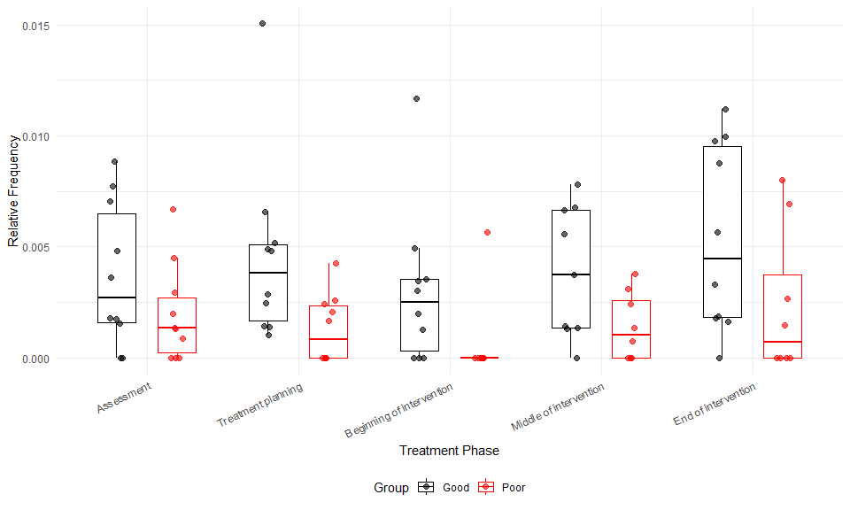

```r
results <- sequence_descriptives(
  data = data,
  treatment_phase_var = "Treatment_Phase",
  phase_order = c("Assessment", "Treatment planning", "Beginning of intervention",
                  "Middle of intervention", "End of intervention"),
  behavior_var = "Behavior",
  sequence = c("Empathy T", "Total agreement C"),
  combine_plots = T,  # FALSE for separate plots per group
  group_var = "Group",
  selected_groups = c("Good", "Poor"),
  use_relative_frequency = T
)
```

```r
library(DT)

stats_df <- results$statistics


numeric_cols <- names(stats_df)[sapply(stats_df, is.numeric)]

datatable(stats_df,
          options = list(
            pageLength = 5,
            scrollX = TRUE,
            dom = 'Bfrtip'
          )) %>%
  formatRound(columns = setdiff(numeric_cols, "Sample_Size"), digits = 3) %>%
  formatRound(columns = "Sample_Size", digits = 0)
```

|  | Sequence | Group | Treatment_Phase | Sample_Size | Mean | Median | SD | Percentile_5 | Percentile_95 | Skewness | Skewness_SE | Kurtosis | Shapiro_p_value | Normality |
| --- | --- | --- | --- | --- | --- | --- | --- | --- | --- | --- | --- | --- | --- | --- |
| 1 | Empathy T -&gt; Total agreement C | Poor | Assessment | 10 | 0.001965111291431792 | 0.00133176203725035 | 0.002191742159319497 | 0 | 0.005702917771883287 | 0.9313268983734222 | 0.7745966692414834 | -0.4587498797440812 | 0.06870047805766037 | Normal |
| 2 | Empathy T -&gt; Total agreement C | Poor | Treatment planning | 10 | 0.001304481087974146 | 0.0008361204013377926 | 0.00152726187103685 | 0 | 0.003516571011511792 | 0.5404433415218907 | 0.7745966692414834 | -1.208774620560805 | 0.02499003443687209 | Not Normal |
| 3 | Empathy T -&gt; Total agreement C | Poor | Beginning of intervention | 10 | 0.0005660377358490565 | 0 | 0.001789968486887762 | 0 | 0.003113207547169805 | 2.276839915321233 | 0.7745966692414834 | 3.57 | 1.003692813889069e-07 | Not Normal |
| 4 | Empathy T -&gt; Total agreement C | Poor | Middle of intervention | 8 | 0.001422923764550072 | 0.001048426656373389 | 0.001505044883097133 | 0 | 0.003536857890127784 | 0.3548577946292308 | 0.8660254037844386 | -1.739625583313503 | 0.1592628197696983 | Normal |
| 5 | Empathy T -&gt; Total agreement C | Poor | End of intervention | 8 | 0.002382187058286354 | 0.000725689404934688 | 0.003297524749314356 | 0 | 0.007636505212306127 | 0.7609017941339445 | 0.8660254037844386 | -1.345130395563188 | 0.009674081757929429 | Not Normal |
| 6 | Empathy T -&gt; Total agreement C | Good | Assessment | 10 | 0.003711139236329813 | 0.002688382262582092 | 0.00324992929889618 | 0 | 0.008360399799158976 | 0.3292863047443835 | 0.7745966692414834 | -1.633168056985955 | 0.2355920886214405 | Normal |
| 7 | Empathy T -&gt; Total agreement C | Good | Treatment planning | 10 | 0.004569691087104776 | 0.003839078758760963 | 0.004150706430636162 | 0.001184825739693537 | 0.01125032859771638 | 1.464360010181841 | 0.7745966692414834 | 1.249113152396733 | 0.006927934002503871 | Not Normal |
| 8 | Empathy T -&gt; Total agreement C | Good | Beginning of intervention | 10 | 0.002995335430170191 | 0.002502331411230955 | 0.003510288577775604 | 0 | 0.008660339386483371 | 1.337465789619233 | 0.7745966692414834 | 0.9404173011670229 | 0.01401935931743301 | Not Normal |
| 9 | Empathy T -&gt; Total agreement C | Good | Middle of intervention | 9 | 0.003845268636649434 | 0.003738317757009346 | 0.00292889975618347 | 0.0005167958656330749 | 0.007405475880052151 | 0.0521658113680538 | 0.816496580927726 | -1.899548615835817 | 0.2145892762412848 | Normal |
| 10 | Empathy T -&gt; Total agreement C | Good | End of intervention | 10 | 0.005389385476562707 | 0.004469226119437685 | 0.004192024727674112 | 0.0007293354943273904 | 0.01063488390033171 | 0.1397838716976432 | 0.7745966692414834 | -1.88292321754374 | 0.1384253237572789 | Normal |

# 3. Data analyses: answering the proposed research questions

## 3.1 What behaviors/sequences are more frequent?

The `sequence_heatmap` function is designed to analyze and visualize individual or sequences of behaviors. It generates a heatmap that displays the absolute or relative frequency of specific behaviors or sequences of behaviors across different moments (e.g., treatment phases). The function is highly customizable, allowing users to define behaviors/sequences and treatment phases, as well as specify the type of data desired (absolute or relative frequency). The researcher will also be able to flexibly group behaviors that they want to be treated as the same using a `+`, without permanently changing the data frame. It also allows for group comparison.

### Key Features

1. **Behavior and Sequence Analysis**:
   - Handles grouped behaviors flexibly (e.g., `"BehaviorA + BehaviorB"`), treating them as one single behavior.
2. **Customizable Inputs**:
   - Users can specify the columns for behaviors, treatment phases, and sessions in the dataset.
   - Allows customization of treatment phase levels and the order of behaviors/sequences in the heatmap.
3. **Frequency Calculation**:
   - Computes **absolute frequencies** (counts) or **relative frequencies** (proportions) of behaviors or sequences.
   - Calculates mean frequencies per phase by normalizing the sum of frequencies by the total number of sessions in each phase.
4. **Heatmap Visualization**:
   - Generates a heatmap using `ggplot2`, with behaviors/sequences on the y-axis and treatment phases on the x-axis.
   - The fill color of the heatmap represents the absolute or relative frequency of behaviors/sequences.
5. **Custom Ordering**:
   - Allows users to order behaviors/sequences in the heatmap either:
     - **Personalized**: In the same order as provided in `custom_sequences`.
     - **By Frequency**: Based on the total frequency of behaviors/sequences (highest to lowest).
6. **Group Separation**:
   - Supports separation of data by groups (e.g., `"Good"`, `"Poor"`) if a `group_var` is provided.
   - Generates separate heatmaps for each group, ensuring that the analysis is tailored to each subset of the data.
7. **Requested Libraries Handling**:
   - Checks for and loads required packages (`dplyr`, `ggplot2`, `tidyr`, `purrr`, `stringr`) and installs them if they are not installed.

### Function Arguments

[output not shown]

### Function syntax

```r
sequence_heatmap <- function(
    data,
    behavior_col = "Behavior",
    phase_col = "Treatment_Phase",
    session_col = "Observation",
    custom_sequences,
    phase_levels = NULL,
    freq_type = "absolute",
    custom_order = "personalized",
    group_var = NULL,
    selected_groups = NULL) {

  # Load libraries
  suppressWarnings({
    required_packages <- c("dplyr", "ggplot2", "tidyr", "purrr", "stringr")
    missing <- setdiff(required_packages, rownames(installed.packages()))
    if (length(missing) > 0) install.packages(missing)
    lapply(required_packages, library, character.only = TRUE)
  })

  # Helper
  process_behavior_group <- function(behavior) {
    strsplit(behavior, " \\+ ")[[1]] %>% trimws()
  }

  match_sequence <- function(observed, expected_seq) {
    if (length(observed) < length(expected_seq)) return(FALSE)
    for (i in seq_along(expected_seq)) {
      expected_behaviors <- process_behavior_group(expected_seq[i])
      if (!(observed[i] %in% expected_behaviors)) return(FALSE)
    }
    return(TRUE)
  }

  # Phase levels
  if (!is.null(phase_levels)) {
    data[[phase_col]] <- factor(data[[phase_col]], levels = phase_levels, ordered = TRUE)
  }

  # Filter by group
  if (!is.null(group_var) && !is.null(selected_groups)) {
    data <- data %>% filter(.data[[group_var]] %in% selected_groups)
  }

  # Determine group levels
  group_levels <- if (!is.null(group_var)) unique(data[[group_var]]) else list(NULL)

  for (group in group_levels) {
    data_group <- if (!is.null(group_var)) data %>% filter(.data[[group_var]] == group) else data

    # Prepare list of all sessions + phases
    data_group <- data_group %>%
      arrange(.data[[session_col]], .data[[phase_col]]) %>%
      group_by(.data[[session_col]], .data[[phase_col]]) %>%
      summarise(Behaviors = list(.data[[behavior_col]]), .groups = "drop")

    # Empty result holder
    results <- list()

    # Iterate over custom_sequences
    for (seq in custom_sequences) {
      seq_label <- paste(seq, collapse = " -> ")

      if (length(seq) == 1) {
        # Individual behavior
        target_behaviors <- process_behavior_group(seq)

        matched <- data_group %>%
          rowwise() %>%
          mutate(
            Frequency = sum(Behaviors %in% target_behaviors)
          ) %>%
          filter(Frequency > 0) %>%
          ungroup() %>%
          mutate(GroupSequence = seq_label)

        results[[seq_label]] <- matched

      } else {
        # Sequence of behaviors
        matched <- data_group %>%
          rowwise() %>%
          mutate(
            Frequency = sum(sapply(1:(length(Behaviors) - length(seq) + 1), function(i) {
              observed_slice <- Behaviors[i:(i + length(seq) - 1)]
              match_sequence(observed_slice, seq)
            }))
          ) %>%
          filter(Frequency > 0) %>%
          ungroup() %>%
          mutate(GroupSequence = seq_label)

        results[[seq_label]] <- matched
      }
    }

    all_matches <- bind_rows(results)

    # Add total sequences/behaviors per session for relative frequency
    if (freq_type == "relative") {
      total_counts <- data_group %>%
        rowwise() %>%
        mutate(Total = max(length(Behaviors) - 1, 1)) %>%
        ungroup() %>%
        select(.data[[session_col]], .data[[phase_col]], Total)

      all_matches <- all_matches %>%
        left_join(total_counts, by = c(session_col, phase_col)) %>%
        mutate(Frequency = Frequency / Total)
    }

    # Average across sessions
    summary_data <- all_matches %>%
      group_by(GroupSequence, .data[[phase_col]]) %>%
      summarise(Frequency = mean(Frequency), .groups = "drop")

    # Order
    if (custom_order == "personalized") {
      order_labels <- map_chr(custom_sequences, ~ paste(.x, collapse = " -> "))
      summary_data$GroupSequence <- factor(summary_data$GroupSequence, levels = rev(order_labels), ordered = TRUE)
    } else if (custom_order == "frequency") {
      summary_data <- summary_data %>% arrange(desc(Frequency))
      summary_data$GroupSequence <- factor(summary_data$GroupSequence, levels = rev(unique(summary_data$GroupSequence)), ordered = TRUE)
    }

    if (!is.null(phase_levels)) {
      summary_data[[phase_col]] <- factor(summary_data[[phase_col]], levels = phase_levels)
    }

    # Plot
    p <- ggplot(summary_data, aes(x = .data[[phase_col]], y = GroupSequence, fill = Frequency)) +
      geom_tile(color = "white") +
      scale_fill_gradient(low = "white", high = "black") +
      theme_minimal() +
      labs(
        title = if (!is.null(group_var)) paste("Sequences Heatmap - Group:", group) else "Sequences Heatmap",
        x = "Treatment Phase",
        y = "Sequences / Behaviors",
        fill = ifelse(freq_type == "absolute", "Absolute Frequency", "Relative Frequency")
      ) +
      theme(axis.text.x = element_text(angle = 45, hjust = 1))

    print(p)
  }
}
```

### Output: example usage

The function returns a heatmap or various heatmaps depending if the group argument includes a group variable. The following callings show different possible outputs.

#### 2 groups compared - Relative frequency - Personalized order

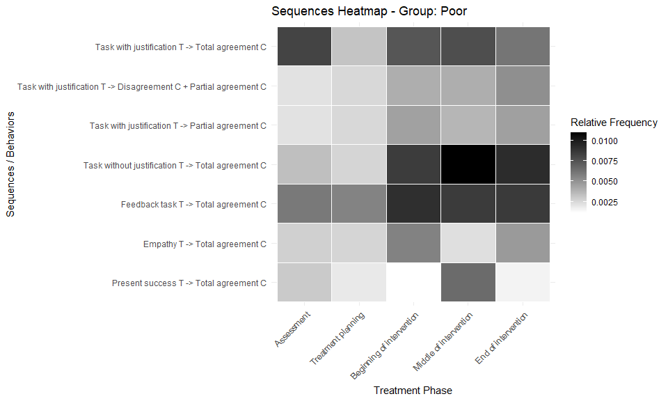

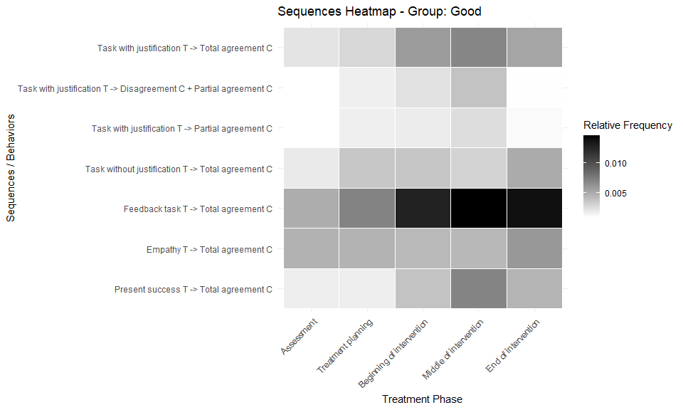

```r
sequence_heatmap(
  data = data,
  behavior_col = "Behavior",
  phase_col = "Treatment_Phase",
  session_col = "Observation",
  custom_sequences = list(
    c("Task with justification T", "Total agreement C"),
    c("Task with justification T", "Disagreement C + Partial agreement C"),
    c("Task with justification T", "Partial agreement C"),
    c("Task without justification T", "Total agreement C"),
    c("Feedback task T", "Total agreement C"),
    c("Empathy T", "Total agreement C"),
    c("Present success T", "Total agreement C")
  ),
  phase_levels = c("Assessment", "Treatment planning", "Beginning of intervention", "Middle of intervention", "End of intervention"),
  freq_type = "relative",
  custom_order = "personalized",
  group_var = "Group",
  selected_groups = c("Good", "Poor")
)
```

#### No group comparison - Absolute frequency - Order by total frequency

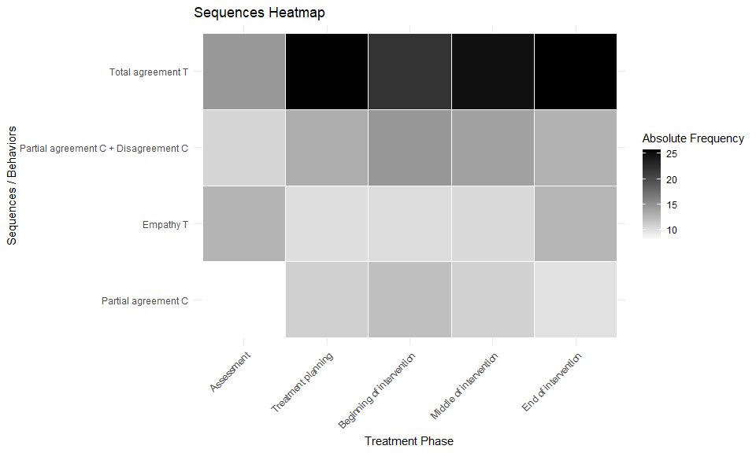

```r
sequence_heatmap(
  data = data,
  behavior_col = "Behavior",
  phase_col = "Treatment_Phase",
  session_col = "Observation",
  custom_sequences = list(
    c("Total agreement T"),
    c("Empathy T"),
    c("Partial agreement C"),
    c("Task without justification", "Total agreement C"),
    c("Partial agreement C + Disagreement C")),
  phase_levels = c("Assessment", "Treatment planning", "Beginning of intervention", "Middle of intervention", "End of intervention"),
  freq_type = "absolute",
  custom_order = "frequency",
  group_var = NULL,
  selected_groups = c("Good", "Poor") # Only works if group_var is not NULL
)
```

## 3.2 How do behaviors/sequences evolve over time?

The `sequence_trajectory` function models how specific behavior sequences evolve across treatment phases using a standardized metric to allow comparison between different behaviors/sequences and different groups. It enables researchers to explore patterns of change (e.g., increasing, decreasing, stable) in the relative frequency of sequences, optional comparisons between groups. The function supports multiple polynomial shapes (linear, quadratic, cubic) to fit and visualize behavioral trends.

### Key Features

1. **Trajectory Modeling**:
   - Computes the relative frequency in a standardized metric of specific behaviors or behavior sequences across treatment phases.
   - Aggregates and averages frequencies to identify trends across sessions.
2. **Group-Based Analysis**:
   - If a grouping variable is provided, trajectories are computed separately for each group (e.g., `"Good"` vs `"Poor"`), enabling comparative analysis.
3. **Behavior Grouping with Flexibility**:
   - Supports combined behavior analysis using the `+` operator (e.g., `"BehaviorA + BehaviorB"`) for evaluating equivalent/similar behaviors.
4. **Clean Visualization**:
   - Plots behavioral trajectories using `ggplot2` with clear phase separation and optional faceting by group.
5. **Phase Control**:
   - Users can control the ordering of treatment phases.

### Argument Descriptions

| Argument | Description |
| --- | --- |
| `data` | The input data frame containing behavioral observation data. |
| `sequence` | A character vector (or list of vectors) representing the target behavior and/or sequence(s) to analyze. Each sequence is matched as an exact temporal pattern. |
| `behavior_var` | The column name containing behavior codes (default: `"Behavior"`). |
| `phase_var` | The column name indicating treatment phases (default: `"Treatment_Phase"`). |
| `phase_order` | Optional. A vector specifying the desired order of phases. If `NULL`, the function uses the factor levels in the data. |
| `observation_var` | Column identifying individual observations/sessions (default: `"Observation"`). |
| `id_var` | Column identifying unique subjects or participants (default: `"ID"`). |
| `group_variable` | Optional. The column name for a grouping variable (e.g., `"Group"`). Required if comparing across groups. |
| `groups_compared` | Optional. A vector of group labels to include in the analysis (e.g., `c("Treatment", "Control")`). Required if `group_variable` is specified. |
| `shapes` | A character vector indicating the polynomial shapes to fit: `"linear"`, `"quadratic"`, and/or `"cubic"` (default includes all three). |

### Function syntax

```r
sequence_trajectory <- function(
    data,
    sequence,  # Can be a list of sequences
    behavior_var = "Behavior",
    phase_var = "Treatment_Phase",
    phase_order = NULL,
    observation_var = "Observation",
    id_var = "ID",
    group_variable = NULL,
    groups_compared = NULL,
    shapes = c("linear", "quadratic", "cubic")) {

  # 1. Package handling
  required_packages <- c("dplyr", "tidyr", "purrr", "ggplot2", "patchwork", "blme")
  suppressWarnings({
    missing_pkgs <- setdiff(required_packages, rownames(installed.packages()))
    if (length(missing_pkgs) > 0) install.packages(missing_pkgs, quiet = TRUE)
    lapply(required_packages, library, character.only = TRUE, quietly = TRUE)
  })

  # 2. Data validation
  required_cols <- c(id_var, observation_var, phase_var, behavior_var)
  if (!all(required_cols %in% colnames(data))) {
    stop("Missing columns: ", paste(setdiff(required_cols, colnames(data)), collapse = ", "))
  }

  # Convert sequence to list if not already
  if (!is.list(sequence)) sequence <- list(sequence)

  if (!is.null(group_variable)) {
    if (!group_variable %in% colnames(data)) {
      stop("Group variable not found in data.")
    }
    if (is.null(groups_compared)) {
      stop("Please specify groups to compare using 'groups_compared'")
    }
    data <- data %>% filter(!!sym(group_variable) %in% groups_compared)
  }

  # 3. Helper functions
  process_behavior_group <- function(group) {
    strsplit(group, " \\+ ")[[1]] %>% trimws()
  }

  match_sequence <- function(behavior_list, seq) {
    if (length(behavior_list) < length(seq)) return(FALSE)
    for (i in seq_along(seq)) {
      expected_behaviors <- process_behavior_group(seq[i])
      observed_behavior <- behavior_list[i]
      if (!(observed_behavior %in% expected_behaviors)) return(FALSE)
    }
    return(TRUE)
  }

  mean_cl_normal_custom <- function(x) {
    m <- mean(x, na.rm = TRUE)
    s <- sd(x, na.rm = TRUE)
    n <- sum(!is.na(x))
    se <- s/sqrt(n)
    data.frame(y = m, ymin = m - 1.96*se, ymax = m + 1.96*se)
  }

  # 4. Analysis logic for a single sequence
  run_analysis <- function(data_sub, current_sequence, group_name = NULL) {
    data_processed <- data_sub %>%
      rename(
        Behavior = !!sym(behavior_var),
        Observation = !!sym(observation_var),
        ID = !!sym(id_var),
        Treatment_Phase = !!sym(phase_var)
      ) %>%
      group_by(ID, Observation) %>%
      summarise(
        sequence_count = sum(
          sapply(1:(n() - length(current_sequence) + 1), function(i) {
            behavior_window <- Behavior[i:(i + length(current_sequence) - 1)]
            match_sequence(behavior_window, current_sequence)
          })
        ),
        .groups = "drop"
      ) %>%
      left_join(
        data_sub %>%
          rename(
            Observation = !!sym(observation_var),
            ID = !!sym(id_var),
            Treatment_Phase = !!sym(phase_var)
          ) %>%
          distinct(ID, Observation, Treatment_Phase),
        by = c("ID", "Observation")
      ) %>%
      group_by(ID, Treatment_Phase) %>%
      summarise(
        total_sequences = sum(sequence_count, na.rm = TRUE),
        .groups = "drop"
      ) %>%
      group_by(ID) %>%
      mutate(
        rel_frequency = total_sequences / sum(total_sequences, na.rm = TRUE)
      ) %>%
      ungroup()

    if (!is.null(phase_order)) {
      data_processed <- data_processed %>%
        mutate(Treatment_Phase = factor(Treatment_Phase, levels = phase_order))
    } else {
      data_processed <- data_processed %>%
        mutate(Treatment_Phase = factor(Treatment_Phase))
    }

    data_processed <- data_processed %>%
      mutate(time_points = as.numeric(Treatment_Phase))

    # FIXED y-axis: ALWAYS crop to 0.75 (all plots identical)
    y_upper <- 0.75

    # Model fitting
    fit_results <- list()
    for (shape in shapes) {
      fit_results[[shape]] <- tryCatch({
        if (shape == "linear") {
          blmer(rel_frequency ~ time_points + (1 | ID),
                data = data_processed,
                cov.prior = wishart)
        } else if (shape == "quadratic") {
          blmer(rel_frequency ~ poly(time_points, 2) + (1 | ID),
                data = data_processed,
                cov.prior = wishart)
        } else if (shape == "cubic") {
          blmer(rel_frequency ~ poly(time_points, 3) + (1 | ID),
                data = data_processed,
                cov.prior = wishart)
        }
      }, error = function(e) {
        warning(paste("Model fitting failed for", shape, ":", e$message))
        NULL
      })
    }

    # Model comparison
    fit_comparison <- map_dfr(
      fit_results,
      function(mod) {
        if (is.null(mod)) {
          tibble(AIC = NA_real_, BIC = NA_real_)
        } else {
          tibble(AIC = stats::AIC(mod), BIC = stats::BIC(mod))
        }
      },
      .id = "Model"
    )

    if (all(is.na(fit_comparison$AIC))) {
      best_fit <- NA_character_
    } else {
      fit_comparison <- arrange(fit_comparison, AIC)
      best_fit <- fit_comparison$Model[1]
    }

    # Create plot title
    plot_title <- paste(paste(current_sequence, collapse = " -> "))
    if (!is.null(group_name)) {
      plot_title <- paste(plot_title, "-", group_name)
    }

    # Plot - FIXED y-axis at 0.75, lines cropped
    plot <- ggplot(data_processed, aes(x = Treatment_Phase, y = rel_frequency)) +
      geom_line(aes(group = ID), color = "gray70", alpha = 0.5) +
      geom_point(aes(group = ID), color = "gray50", size = 1, alpha = 0.3) +
      stat_summary(aes(group = 1), fun = mean, geom = "line", color = "blue", size = 1.5) +
      stat_summary(fun.data = mean_cl_normal_custom, geom = "errorbar", width = 0.1, color = "blue") +
      coord_cartesian(ylim = c(0, 0.75), clip = "on") +
      scale_y_continuous(breaks = c(0, 0.25, 0.50, 0.75)) +
      labs(
        title = plot_title,
        x = phase_var,
        y = "Relative Frequency"
      ) +
      theme_minimal()+
      theme(
        plot.title = element_text(size = 8, hjust = 0.5),
        axis.text.x = element_text(size = 8, angle = 15, hjust = 1),
        plot.margin = margin(5, 7, 5, 7)
      )

    # Prediction line
    if (!is.na(best_fit) && !is.null(fit_results[[best_fit]])) {
      pred_data <- data.frame(
        time_points = unique(data_processed$time_points)
      )

      pred_data$rel_frequency <- predict(
        fit_results[[best_fit]],
        newdata = pred_data,
        re.form = NA
      )

      pred_data$Treatment_Phase <- factor(
        levels(data_processed$Treatment_Phase)[pred_data$time_points],
        levels = levels(data_processed$Treatment_Phase)
      )

      plot <- plot +
        geom_line(
          data = pred_data,
          aes(x = Treatment_Phase, y = rel_frequency, group = 1),
          color = "red",
          size = 1.2
        ) +
        annotate(
          "text", x = Inf, y = Inf,
          label = paste("Best fit:", best_fit, "\nAIC:", round(fit_comparison$AIC[1], 1)),
          hjust = 1.1, vjust = 1.1, size = 3
        )
    }

    list(
      data_processed = data_processed,
      fit_results = fit_results,
      fit_comparison = fit_comparison,
      best_fit = best_fit,
      plot = plot
    )
  }

  # 5. Main analysis logic
  if (is.null(group_variable)) {
    results <- map(sequence, ~ run_analysis(data, .x))
    names(results) <- map_chr(sequence, ~ paste("Sequence:", paste(.x, collapse = " -> ")))

    return(list(
      individual_sequences = results,
      all_sequences_plot = wrap_plots(map(results, "plot"), ncol = length(sequence))
    ))
  } else {
    data_filtered <- data %>% filter(!!sym(group_variable) %in% groups_compared)
    group_list <- split(data_filtered, data_filtered[[group_variable]])

    group_results <- map(groups_compared, function(group) {
      seq_results <- map(sequence, ~ {
        list(
          results = run_analysis(group_list[[group]], .x, group_name = group),
          label = paste("Group", group, "|", paste(.x, collapse = " -> "))
        )
      })
      names(seq_results) <- map_chr(sequence, ~ paste("Sequence:", paste(.x, collapse = " -> ")))

      list(
        group = group,
        sequences = seq_results,
        group_plot = wrap_plots(map(seq_results, ~ .x$results$plot), ncol = 1)
      )
    })
    names(group_results) <- paste("Group", groups_compared)

    all_plots <- map(group_results, ~ map(.x$sequences, ~ .x$results$plot)) %>%
      flatten()
    comparison_plot <- wrap_plots(all_plots, ncol = length(groups_compared))

    return(list(
      by_group = group_results,
      comparison_plot = comparison_plot
    ))
  }
}
```

### Output: example usage

The function returns a list with plots and model information:

Each plot includes: - Individual lines for each subject. - Group average trajectory with confidence intervals. - Best-fit polynomial model (in red) with AIC info.

#### Two single behaviors compared

The output shown answers the research question *How do behaviors/sequences evolve over time?*, so the `group_variable` argument is `NULL`.

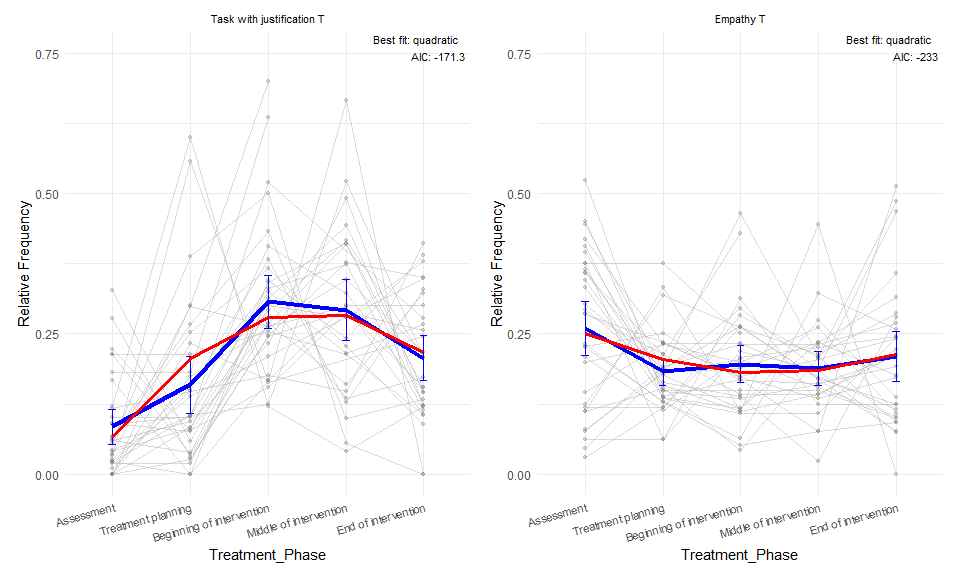

```r
# Two single behaviors compared

result <- sequence_trajectory(
  data = data,
  sequence = list(c("Task with justification T"), c("Empathy T")),
  behavior_var = "Behavior",
  phase_var = "Treatment_Phase",
  phase_order = c("Assessment", "Treatment planning", "Beginning of intervention", "Middle of intervention", "End of intervention"),
  observation_var = "Observation",
  id_var = "ID",
  group_variable = NULL,
  groups_compared = NULL,
  shapes = c("linear", "quadratic", "cubic")
)

result[["all_sequences_plot"]]
```

## 3.3 Do changes in behaviors/sequences differ across groups?

The `sequence_trajectory` allows for comparisons between groups using the argument `group_variable`, which needs to be filled with the name of the variable that contains the groups’ names. In the argument `groups_compared`, we need to indicate which groups from the `group_variable` we want to compare.

### Output

#### One sequence - Two groups compared

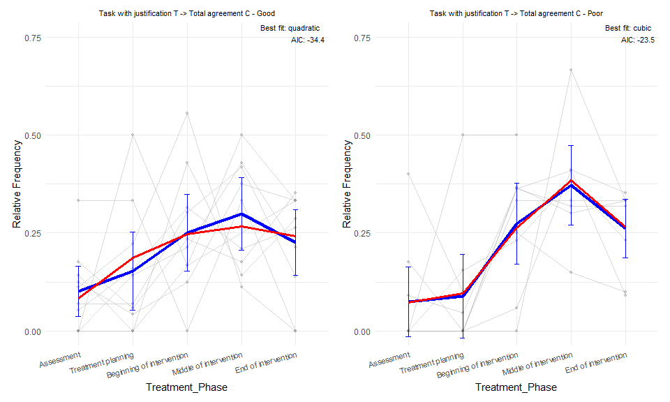

```r
result <- sequence_trajectory(
  data = data,
  sequence = list(c("Task with justification T", "Total agreement C")),
  behavior_var = "Behavior",
  phase_var = "Treatment_Phase",
  phase_order = c("Assessment", "Treatment planning", "Beginning of intervention", "Middle of intervention", "End of intervention"),
  observation_var = "Observation",
  id_var = "ID",
  group_variable = "Group",
  groups_compared = c("Good", "Poor"),
  shapes = c("linear", "quadratic", "cubic")
)

result[["comparison_plot"]]
```

#### Two sequences - Two groups compared

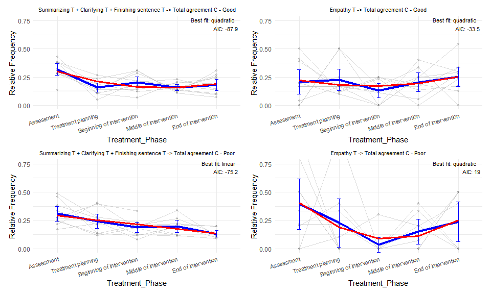

```r
result <- sequence_trajectory(
  data = data,
  sequence = list(c("Summarizing T + Clarifying T + Finishing sentence T", "Total agreement C"), c("Empathy T", "Total agreement C")),
  behavior_var = "Behavior",
  phase_var = "Treatment_Phase",
  phase_order = c("Assessment", "Treatment planning", "Beginning of intervention", "Middle of intervention", "End of intervention"),
  observation_var = "Observation",
  id_var = "ID",
  group_variable = "Group",
  groups_compared = c("Good", "Poor"),
  shapes = c("linear", "quadratic", "cubic")
)

result[["comparison_plot"]]
```